# Gra w chaos na kwadracie i pewna paproć

W niniejszym notatniku zakodujemy grę w chaos oraz wyrysujemy piękne grafiki powstające podczas zajmowania się układami chaotycznymi.

Używam tutaj jądra SageMath posiadającego wiele wygodnych i pożytecznych funkcji, dzięki czemu nie muszę ich importować z różnych biblitek.

Bardzo skrótowo gra w chaos polega na tym, że losujemy punkt początkowy z pewnego wielokąta na płaszczyźnie lub w przestrzeni (u nas kwadratu jednostkowego na płaszczyźnie), następnie losujemy jeden z wierzchołków tego wielokąta i zaznaczamy nowy punkt na środku odcinka łączącego stary punkt z wylosowanym wierzołkiem. Procedurę tę powtarzamy wiele razy i zaznaczamy kolejno powstałe punkty na wykresie patrząc jak wygląda ich zbiór - czy nie przyjmuje jakiejś ciekawej postaci. Okazuje się, że w przypadku takiej gry te zbiory punktów układają się w bardzo ciekawe kształty.

Grę możemy również urozmaicić nakładając dodatkowe warunki na to, jak losowane są kolejne punkty. Warunki te opisane są w dalszej części tego notatnika. Można również przeczytać o nich również na angielskiej Wikipedii https://en.wikipedia.org/wiki/Chaos_game

Przejdźmy do implementacji gry w chaos.

Poniższa funkcja losuje jedną z liczb od 1 do 4, jeśli argument ${\tt bez} = 0,$ natomiast jeśli ${\tt bez} = x,$ dla $x \in \{1,2,3,4\},$ to funkcja losuje liczbę ze zbioru $\{1,2,3,4\} \backslash \{x\},$ czyli ze zbioru $\{1,2,3,4\}$ bez x, stąd nazwa argumentu opcjonalnego.

```python
def losuj_wierzcholek(bez = 0):
    if bez == 0:
        return randint(1,4)
    else:
        lista = [1,2,3,4]
        lista.remove(bez)
        return choice(lista)
```

Funkcja losująca punkt z kwadratu z rozkładu jednostajnego na tym kwadracie.

```python
def losuj_punkt():
    return (uniform(0, 1),uniform(0, 1))
```

Funkcja ${\tt nowy_\_punkt}$ przyjmuje jako argument M, będący punktem z kwadratu jednostkowego. Losuje ona jeden z czterech wierzchołków kwadratu i zwraca nowy punkt, który leży na środku odcinka leżącego między podanym punktem M oraz wylosowanym wierzchołkiem kwadratu.

Przykładowo, jeśli M = (0.5, 0.5) oraz wylosujemy wierzchołek (1,1), to funkcja zwórci nowy punkt (0.75, 0.75).

Dodatkowo, funkcja "zapamiętuje" który wierzchołek został wylosowany w danym momencie umieszczając numer wylosowanego wierzchołka na drugim miejscu zwracanej listy.

```python
def nowy_punkt(M, bez = 0):

    wierzcholek = (0,0)
    nr = losuj_wierzcholek(bez)

    if nr == 1:
        wierzcholek = (1,0)
    elif nr == 2:
        wierzcholek = (1,1)
    elif nr == 3:
        wierzcholek = (0,1)
    # jezeli nr == 4 to zostaje (0,0)

    return( [( (M[0]+wierzcholek[0])/2 , (M[1]+wierzcholek[1])/2 ), nr ])
```

M - punkt początkowy z kwadratu jednostkowego

n - liczba iteracji, czyli liczba punktów które powstają w wyniku "grania w grę w chaos"

warunek - wariant gry w którą gramy, czyli nałożenie ograniczenia na wybór wierzchołka w kolejnej iteracji (szczegóły są opisane niżej)

Warunki odpowiadają różnym wariantom gry w chaos. W grze z warunkiem równym 2 jeśli nowy punkt powstał przez przesunięcie starego punktu w stronę wierzchołka X, gdzie $X \in \{1,2,3,4\},$ to w kolejnej iteracji nie możemy wylosować wierzchołka, który "jest poprzednikiem X względem ruchu zgodnie z ruchem wskazówek zegara".

Aby zabrzmiało to jaśniej - poprzednikiem punktu (1,0) jest (0,0),

punktu (1,1) - (1,0),

punktu (0,1) - (1,1),

punktu (0,0) - (0,1).

Warunek 3 odpowiada warianowi, w którym jeśli punkt powstał przez starego punktu w stronę danego wierzchołka, to w kolejnym ruchu nie może zostać wylosowany wierzchołek przeciwległy do niego.

```python
def chaos(M, n, warunek = 1, bez=0):

    n -= 1
    M = [M, 0]

    if warunek == 1:
        lista = [M[0]]
        for i in range(n):
            M = nowy_punkt(M[0], bez)
            bez = M[1]
            lista += [M[0]]
        show(points(lista, xmin=0,xmax=1,ymin=0,ymax=1,aspect_ratio=1))

    if warunek == 2:
        lista = [M[0]]
        for i in range(n):
            M = nowy_punkt(M[0], bez)
            bez = ( (M[1]+2) % 4)+1
            lista += [M[0]]
        show(points(lista, xmin=0,xmax=1,ymin=0,ymax=1,aspect_ratio=1))

    if warunek == 3:
        lista = [M[0]]
        for i in range(n):
            M = nowy_punkt(M[0], bez)
            bez = ( (M[1]+1) % 4)+1
            lista += [M[0]]
        show(points(lista, xmin=0,xmax=1,ymin=0,ymax=1,aspect_ratio=1))
```

Zobaczmy zbiory punktów powstające w wyniku grania w grę w chaos.

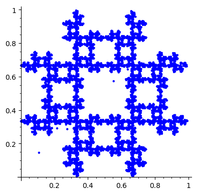

```python
M = losuj_punkt()
chaos(M, 10000, warunek = 1)
```

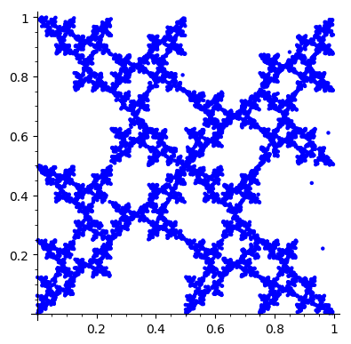

```python
M = losuj_punkt()
chaos(M, 10000, warunek = 2)
```

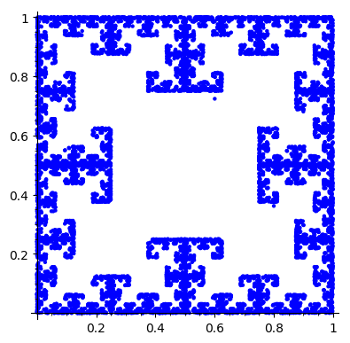

```python
M = losuj_punkt()
chaos(M, 10000, warunek = 3)
```

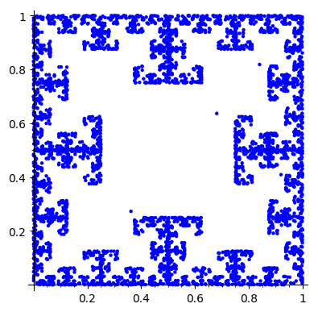

```python
M = losuj_punkt()
chaos(M, 5000, warunek = 3)
```

# Paproć Barnsley'a

Przyjrzyjmy się jeszcze jednemu fraktalowi, a mianowicie paproci Barnsley'a. Najpierw definiujemy cztery proste funkcje, które przekształcają punkt na płaszczyźnie w inny punkt na płaszczyźnie, a następnie funkcję g, która z punktu początkowego za pomocą funkcji f1,f2,f3,f4 tworzy listę punktów, powstałych przez stosowanie tych funkcji najpierw do punktu początkowego, potem do tak powstałych punktów i tak dalej n razy.

Funkcja ta ma złożoność obliczeniową rzędu 4^n, więc nie należy przesadzać wiekością liczby n. Z resztą już dla małych n, np. n=10 otrzymujemy bardzo ładny fraktal.

```python
def f1(punkt):
    x= punkt[0]
    y=punkt[1]
    return (0.85*x+0.04*y,-0.04*x+0.85*y+1.6)
def f2(punkt):
    x= punkt[0]
    y=punkt[1]
    return (-0.15*x+0.28*y,0.26*x+0.24*y+0.44)
def f3(punkt):
    x= punkt[0]
    y=punkt[1]
    return (0.20*x-0.26*y,0.23*x+0.22*y+1.6)
def f4(punkt):
    x= punkt[0]
    y=punkt[1]
    return (0,0.16*y)

def g(punkt):
    return [f1(punkt),f2(punkt),f3(punkt),f4(punkt)]

def gn(punkt, n):
    lista = [punkt]
    for i in range(n):
        lista = [g(punkt)[i] for punkt in lista for i in range(4)]
    return lista
```

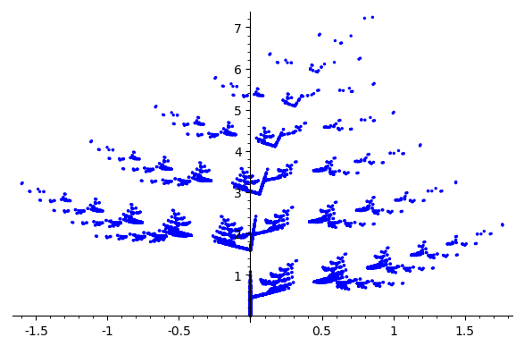

```python
points(gn((0.1,0.2),7), size=6)
```

Dla n=7 fraktal nie jest jeszcze zbyt imponujący, ale dla n=10 wygląda już bardzo ładnie.

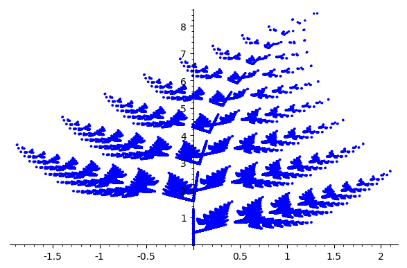

```python
points(gn((0.1,0.2),10), size=6)
```

Zmieniając współczynniki w funkcjach f1, f2, f3 i f4 można zapewne otrzmać mnóstwo innych ciekawych fraktali.